# Competition and Representation in New Mexico’s State House

2026-01-06

## Introduction

This analysis examines elections for New Mexico’s State House from 2004 to 2024, covering all 70 districts over 11 election cycles.

The central question is whether votes translate into seats proportionally. When they don’t — when a party wins more seats than its vote share would justify — that gap is **partisan bias**. Identifying bias is only the first step. The more consequential question is what produces it: district boundaries, geography, or structural features of how races are contested.

Two structural features receive the most attention here: how often races go uncontested, and how competitive districts are when both parties do field candidates. Both shape the distribution of votes across districts in ways that can generate or amplify bias independently of how the map was drawn.

## Data

Election results come from newmexico-political-data, a GitHub resource that collates results from the New Mexico Secretary of State. It covers elections from 2000–2024 with consistent formatting and party names. This analysis focuses on State House races from 2004–2024.

```r
pacman::p_load(dplyr, ggplot2, tidyr, viridis, scales, patchwork, purrr, data.table, sf, ggrepel, tidycensus, tigris, DT)
```

```r
results <- read.csv("https://raw.githubusercontent.com/jaytimm/newmexico-political-data/main/data/elections/nm_election_results_2000-24.csv",
                    stringsAsFactors = FALSE)

house_results <- results |>
  filter(office_name == "State Representative") |>
  filter(election_date >= 2004 & election_date <= 2024)

race_status <- house_results |>
  group_by(election_date, district_name) |>
  summarise(
    n_candidates = n_distinct(candidate_name),
    winner_party = candidate_party_name[is_winner == TRUE][1],
    .groups = "drop"
  ) |>
  mutate(unopposed = n_candidates == 1)

unopposed_summary <- race_status |>
  group_by(election_date) |>
  summarise(
    total_races     = n(),
    unopposed_count = sum(unopposed),
    unopposed_pct   = (unopposed_count / total_races) * 100,
    .groups = "drop"
  )
```

## Representational Fairness

The seats-votes curve is the first diagnostic. Each point plots a party’s statewide vote share against its seat share for a given cycle — proportional representation sits on the diagonal, and deviation from it measures bias. The consistent above-diagonal clustering confirms a modest but durable pro-Democratic bias, present in nearly every cycle and most pronounced in 2020. The one exception was 2014, when Republicans briefly held a slight seat advantage.

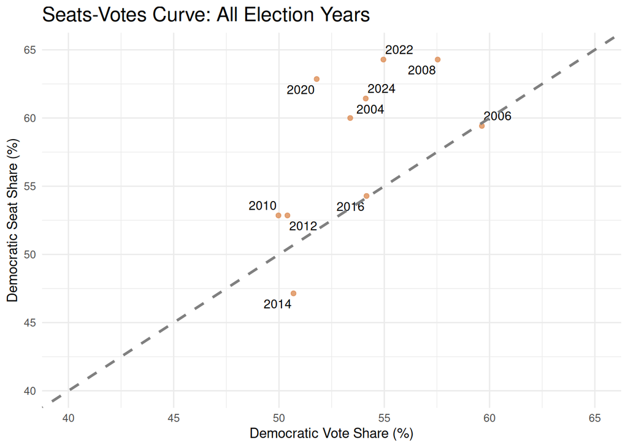

```r
calculate_seats_votes <- function(election_data) {
  election_data |>
    group_by(district_name) |>
    mutate(
      total_votes = sum(votes, na.rm = TRUE),
      dem_votes = sum(votes[candidate_party_name == "Democratic"], na.rm = TRUE),
      rep_votes = sum(votes[candidate_party_name == "Republican"], na.rm = TRUE),
      dem_pct = (dem_votes / total_votes) * 100,
      rep_pct = (rep_votes / total_votes) * 100
    ) |>
    slice(1) |>
    ungroup() |>
    summarise(
      dem_seats = sum(dem_pct > 50, na.rm = TRUE),
      rep_seats = sum(rep_pct > 50, na.rm = TRUE),
      dem_seat_share = (sum(dem_pct > 50, na.rm = TRUE) / n()) * 100,
      dem_vote_share = (sum(dem_votes, na.rm = TRUE) / sum(total_votes, na.rm = TRUE)) * 100,
      .groups = "drop"
    )
}

all_elections <- unique(house_results$election_date)

seats_votes <- map_dfr(all_elections, function(year) {
  sv_result <- calculate_seats_votes(house_results |> filter(election_date == year))
  sv_result$election_date <- year
  sv_result
}) |>
  arrange(election_date)

ggplot(seats_votes, aes(x = dem_vote_share, y = dem_seat_share)) +
  geom_point(color = "#DD8E58", size = 1.5, alpha = 0.8) +
  ggrepel::geom_text_repel(aes(label = election_date), size = 3.5, min.segment.length = 0.5) +
  geom_abline(slope = 1, intercept = 0, linetype = "dashed", color = "grey50", linewidth = 1) +
  labs(
    title = "Seats-Votes Curve: All Election Years",
    x = "Democratic Vote Share (%)",
    y = "Democratic Seat Share (%)"
  ) +
  theme_minimal() +
  theme(plot.title = element_text(size = 16)) +
  xlim(40, 65) +
  ylim(40, 65)
```

### Seats-Votes Summary Table

```r
seats_votes_table <- seats_votes |>
  mutate(
    dem_vote_share = round(dem_vote_share, 1),
    dem_seat_share = round(dem_seat_share, 1),
    seat_vote_diff = round(dem_seat_share - dem_vote_share, 1)
  ) |>
  select(election_date, dem_vote_share, dem_seat_share, seat_vote_diff, dem_seats, rep_seats) |>
  arrange(election_date)

max_abs_diff <- max(abs(seats_votes_table$seat_vote_diff), na.rm = TRUE)
color_func <- scales::col_numeric(
  palette = "RdBu",
  domain = c(-max_abs_diff, max_abs_diff),
  reverse = FALSE
)

seats_votes_table <- seats_votes_table


seats_votes_table |>
  DT::datatable(
    colnames = c("Year", "Dem Vote Share (%)",
                 "Dem Seat Share (%)", "Seat-Vote Diff", "Dem Seats", "Rep Seats"),
    caption = "Seats-Votes Relationship: State House, All Election Years",
    rownames = FALSE,
    options = list(pageLength = 25, dom = 't', scrollX = TRUE)
  ) |>
  DT::formatStyle(
    "seat_vote_diff",
    backgroundColor = DT::styleInterval(
      cuts = seq(-max_abs_diff, max_abs_diff, length.out = 20),
      values = color_func(seq(-max_abs_diff, max_abs_diff, length.out = 21))
    )
  ) |>
  DT::formatRound(
    columns = c("dem_vote_share", "dem_seat_share", "seat_vote_diff"),
    digits = 1)
```

| Year | Dem Vote Share (%) | Dem Seat Share (%) | Seat-Vote Diff | Dem Seats | Rep Seats |
| --- | --- | --- | --- | --- | --- |
| 2004 | 53.4 | 60 | 6.6 | 42 | 28 |
| 2006 | 59.6 | 59.4 | -0.2 | 41 | 28 |
| 2008 | 57.5 | 64.3 | 6.8 | 45 | 25 |
| 2010 | 50 | 52.9 | 2.9 | 37 | 33 |
| 2012 | 50.4 | 52.9 | 2.5 | 37 | 32 |
| 2014 | 50.7 | 47.1 | -3.6 | 33 | 37 |
| 2016 | 54.2 | 54.3 | 0.1 | 38 | 32 |
| 2018 | 58.4 | 65.7 | 7.3 | 46 | 24 |
| 2020 | 51.8 | 62.9 | 11.1 | 44 | 25 |
| 2022 | 55 | 64.3 | 9.3 | 45 | 25 |

[output cut: 1 more lines]

## Partisan Distribution and the “Seat Bonus”

The 2024 results — Democrats holding a 43–27 advantage — point to a deeper structural story. To understand why seat share remains disconnected from the statewide vote, the distribution of actual victory margins across the 70 districts is more revealing than the aggregate totals.

Part of that pattern traces directly to uncontested seats. When a significant share of the chamber goes unchallenged each cycle, the effective vote distribution is distorted before a single ballot is cast. The notable drop in unopposed races in 2020 is corroborated by [Ballotpedia’s coverage of that cycle](https://ballotpedia.org/New_Mexico_House_of_Representatives_elections,_2020); aside from that inflection, the floor has remained largely stable.

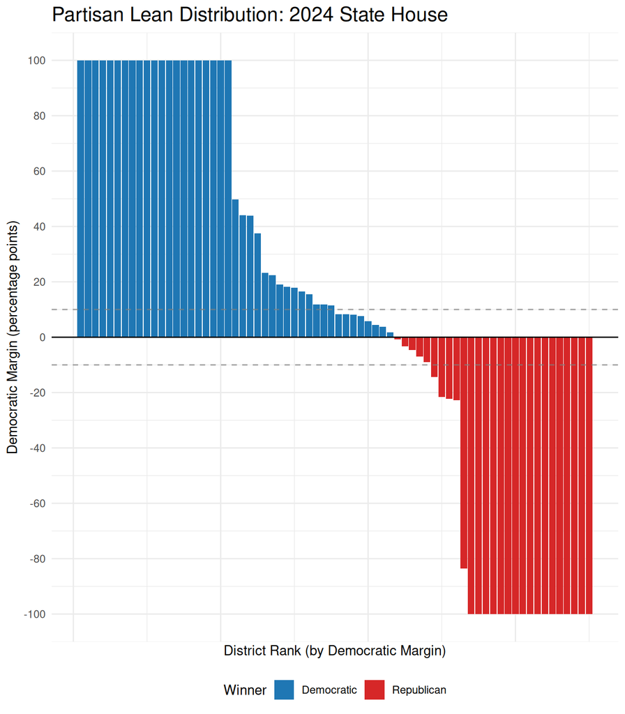

```r
house_2024 <- house_results |>
  filter(election_date == 2024) |>
  group_by(district_name) |>
  mutate(
    total_votes = sum(votes, na.rm = TRUE),
    dem_votes = sum(votes[candidate_party_name == "Democratic"], na.rm = TRUE),
    rep_votes = sum(votes[candidate_party_name == "Republican"], na.rm = TRUE),
    dem_pct = (dem_votes / total_votes) * 100,
    rep_pct = (rep_votes / total_votes) * 100,
    dem_margin = dem_pct - rep_pct
  ) |>
  slice(1) |>
  ungroup() |>
  arrange(desc(dem_margin)) |>
  mutate(
    rank = row_number(),
    winner = ifelse(dem_margin > 0, "Democratic", "Republican"),
    district_num = gsub(".*District (\\d+).*", "\\1", district_name)
  )

ggplot(house_2024, aes(x = rank, y = dem_margin, fill = winner)) +
  geom_col() +
  geom_hline(yintercept = 0, color = "black", linewidth = 0.5) +
  geom_hline(yintercept = c(-10, 10), linetype = "dashed", color = "grey50", alpha = 0.7) +
  scale_fill_manual(values = c("Democratic" = "#1f77b4", "Republican" = "#d62728")) +
  labs(
    title = "Partisan Lean Distribution: 2024 State House",
    x = "District Rank (by Democratic Margin)",
    y = "Democratic Margin (percentage points)",
    fill = "Winner"
  ) +
  theme_minimal() +
  theme(
    plot.title = element_text(size = 16),
    legend.position = "bottom",
    axis.text.x = element_blank(),
    axis.ticks.x = element_blank()
  ) +
  scale_y_continuous(breaks = seq(-100, 100, by = 20), limits = c(-100, 100))
```

```r
unopposed_by_party <- race_status |>
  filter(unopposed) |>
  group_by(election_date, winner_party) |>
  summarise(n = n(), .groups = "drop")
```

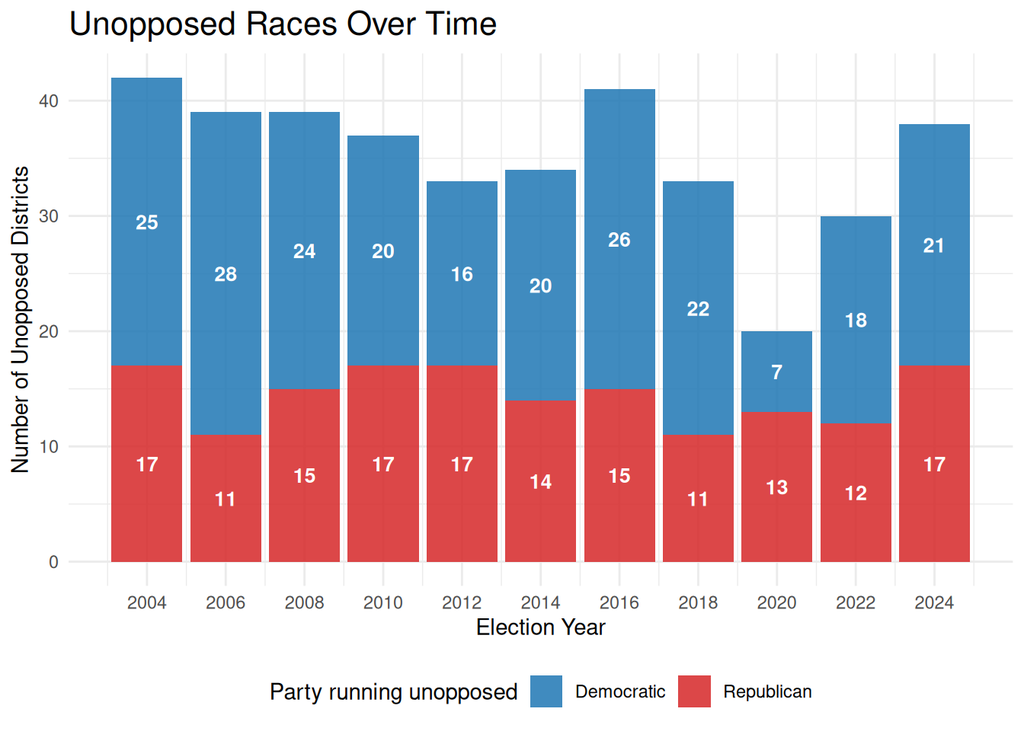

```r
ggplot(unopposed_by_party,
       aes(x = as.numeric(election_date), y = n, fill = winner_party)) +
  geom_col(alpha = 0.85) +
  geom_text(aes(label = n), position = position_stack(vjust = 0.5),
            color = "white", size = 3.5, fontface = "bold") +
  scale_fill_manual(
    values = c("Democratic" = "#1f77b4", "Republican" = "#d62728"),
    name = "Party running unopposed"
  ) +
  labs(
    title = "Unopposed Races Over Time",
    x = "Election Year",
    y = "Number of Unopposed Districts"
  ) +
  theme_minimal() +
  theme(plot.title = element_text(size = 16),
        legend.position = "bottom") +
  scale_x_continuous(breaks = seq(2004, 2024, by = 2))
```

## The Geography of Uncontested Seats

Uncontested seats are not distributed randomly. They cluster in specific regional strongholds — rural, lower-population areas and deep urban pockets — where partisan dominance is sufficient that the minority party consistently declines to field a candidate. This geographic anchor is what keeps the seat bonus durable across redistricting cycles and shifting national environments.

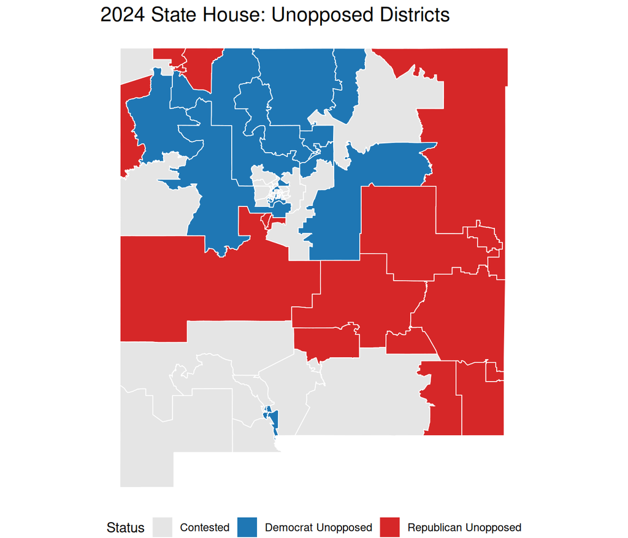

```r
options(tigris_use_cache = TRUE)
invisible(capture.output({
  suppressMessages({
    suppressWarnings({
      house_districts_raw <- tigris::state_legislative_districts(
        state = "NM", house = "lower", year = 2021)
    })
  })
}))

if("SLDLST" %in% names(house_districts_raw)) {
  house_districts <- house_districts_raw |>
    mutate(district_num = as.character(as.numeric(SLDLST))) |>
    select(district_num, geometry)
} else if("NAME" %in% names(house_districts_raw)) {
  house_districts <- house_districts_raw |>
    mutate(
      district_num = gsub(".*District (\\d+).*", "\\1", NAME),
      district_num = as.character(as.numeric(district_num))
    ) |>
    select(district_num, geometry)
} else {
  house_districts <- house_districts_raw |>
    mutate(district_num = as.character(row_number())) |>
    select(district_num, geometry)
}

unopposed_map_house <- race_status |>
  filter(election_date == 2024) |>
  mutate(
    district_num = gsub(".*District (\\d+).*", "\\1", district_name),
    district_num = as.character(as.numeric(district_num)),
    unopposed_status = case_when(
      unopposed & winner_party == "Democratic"  ~ "Democrat Unopposed",
      unopposed & winner_party == "Republican"  ~ "Republican Unopposed",
      TRUE                                       ~ "Contested"
    )
  )

house_map_data <- house_districts |>
  left_join(unopposed_map_house, by = "district_num") |>
  mutate(
    unopposed_status = ifelse(is.na(unopposed_status), "Contested", unopposed_status)
  )

ggplot(house_map_data) +
  geom_sf(aes(fill = unopposed_status), color = "white", linewidth = 0.3) +
  scale_fill_manual(
    values = c("Democrat Unopposed"   = "#1f77b4",
               "Republican Unopposed" = "#d62728",
               "Contested"            = "grey90"),
    name = "Status"
  ) +
  labs(title = "2024 State House: Unopposed Districts") +
  theme_void() +
  theme(
    plot.title = element_text(size = 16),
    legend.position = "bottom"
  )
```

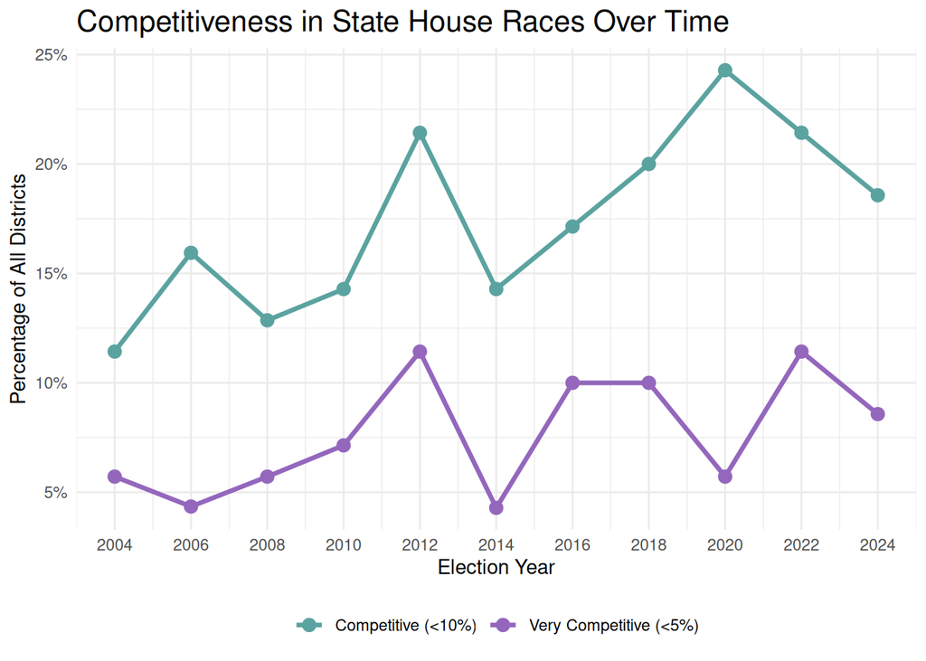

```r
contested_districts <- race_status |>
  filter(!unopposed) |>
  select(election_date, district_name)

house_margins <- house_results |>
  inner_join(contested_districts, by = c("election_date", "district_name")) |>
  group_by(election_date, district_name) |>
  mutate(
    total_votes = sum(votes, na.rm = TRUE),
    dem_votes   = sum(votes[candidate_party_name == "Democratic"], na.rm = TRUE),
    rep_votes   = sum(votes[candidate_party_name == "Republican"], na.rm = TRUE),
    dem_pct     = (dem_votes / total_votes) * 100,
    rep_pct     = (rep_votes / total_votes) * 100,
    margin_abs  = abs(dem_pct - rep_pct),
    competitive_5  = margin_abs < 5,
    competitive_10 = margin_abs < 10
  ) |>
  filter(is_winner == TRUE) |>
  ungroup()

comp_summary <- house_margins |>
  group_by(election_date) |>
  summarise(
    very_competitive = sum(competitive_5, na.rm = TRUE),
    competitive     = sum(competitive_10, na.rm = TRUE),
    .groups = "drop"
  ) |>
  left_join(unopposed_summary |> select(election_date, total_races, unopposed_count), by = "election_date") |>
  pivot_longer(cols = c(very_competitive, competitive),
               names_to = "metric", values_to = "count") |>
  mutate(
    pct = (count / total_races) * 100,
    metric = case_when(
      metric == "very_competitive" ~ "Very Competitive (<5%)",
      metric == "competitive"      ~ "Competitive (<10%)"
    )
  )

ggplot(comp_summary, aes(x = as.numeric(election_date), y = pct, color = metric)) +
  geom_line(linewidth = 1.2) +
  geom_point(size = 3) +
  scale_color_manual(values = c("Very Competitive (<5%)" = "#9467bd",
                                "Competitive (<10%)"     = "#5ba3a0")) +
  labs(
    title = "Competitiveness in State House Races Over Time",
    x = "Election Year",
    y = "Percentage of All Districts",
    color = NULL
  ) +
  theme_minimal() +
  theme(
    plot.title = element_text(size = 16),
    legend.position = "bottom"
  ) +
  scale_x_continuous(breaks = seq(2004, 2024, by = 2)) +
  scale_y_continuous(labels = scales::percent_format(scale = 1))
```

### Competitiveness Summary by Year

```r
house_margins |>
  group_by(election_date) |>
  summarise(
    `Very Competitive (<5%)`  = sum(competitive_5, na.rm = TRUE),
    `Competitive (5-10%)`     = sum(competitive_10 & !competitive_5, na.rm = TRUE),
    `Non-Competitive (>10%)`  = sum(!competitive_10, na.rm = TRUE),
    .groups = "drop"
  ) |>
  left_join(unopposed_summary |> select(election_date, total_races, unopposed_count), by = "election_date") |>
  rename(Year = election_date, Unopposed = unopposed_count) |>
  select(-total_races) |>
  DT::datatable(
    caption = "Competitiveness in State House Races by Year (out of all districts)",
    rownames = FALSE,
    options = list(pageLength = 15, dom = 't', scrollX = TRUE)
  )
```

| Year | Very Competitive (<5%) | Competitive (5-10%) | Non-Competitive (>10%) | Unopposed |
| --- | --- | --- | --- | --- |
| 2004 | 4 | 4 | 20 | 42 |
| 2006 | 3 | 8 | 19 | 39 |
| 2008 | 4 | 5 | 22 | 39 |
| 2010 | 5 | 5 | 23 | 37 |
| 2012 | 8 | 7 | 22 | 33 |
| 2014 | 3 | 7 | 26 | 34 |
| 2016 | 7 | 5 | 17 | 41 |
| 2018 | 7 | 7 | 23 | 33 |
| 2020 | 4 | 13 | 33 | 20 |
| 2022 | 8 | 7 | 25 | 30 |

[output cut: 1 more lines]